# Session1

Natalia Levshina

2026-06-02

## Packages

To reproduce the R code and fit your phylogenetic models, you will need some packages installed and loaded to your session: brms, ape and glottoTrees.

```r
library(brms) #for installation, see the instructions sent previously
library(ape) #install it first if needed via Packages > Install

remotes::install_github("erichround/glottoTrees",
                        dependencies = TRUE)
```

```
## Skipping install of 'glottoTrees' from a github remote, the SHA1 (c81e7156) has not changed since last install.
##   Use `force = TRUE` to force installation
```

```r
library(glottoTrees)
```

## Loading the dataset

Load the data. Note that it should be saved in the working directory. To check your working directory, type this:

```r
getwd()
```

```
## [1] "/Users/natalialevshina/Documents/Conferences/Frejus2026/Session1"
```

After you have copied the dataset, you can load it in R:

```r
data <- read.table("data_session1.txt", header = T, sep = "\t")
#or you can choose it interactively:
#data <- read.table(file = file.choose(), header = T, sep = "\t")
```

Let us explore the dataset.

```r
str(data)
```

```
## 'data.frame':    53 obs. of  9 variables:
##  $ glottocode      : chr  "afri1274" "anci1242" "arab1395" "basq1248" ...
##  $ name            : chr  "Afrikaans" "Ancient Greek" "Arabic" "Basque" ...
##  $ genus           : chr  "Germanic" "Greek" "Semitic" "Basque" ...
##  $ SO_Overlap      : num  0.989 0.206 0.293 0.552 0.5 ...
##  $ Entropy         : num  0.0536 0.8387 0.1909 0.7494 0.3874 ...
##  $ glottocode_genus: chr  "germ1287" "gree1276" "semi1276" "basq1248" ...
##  $ macroarea       : chr  "Africa" "Eurasia" NA "Eurasia" ...
##  $ latitude        : num  -31.6 39.8 31 43.3 53.2 ...
##  $ longitude       : num  20.46 21.91 31 -1.32 25.6 ...
```

```r
head(data)
```

```
##   glottocode          name    genus SO_Overlap    Entropy glottocode_genus
## 1   afri1274     Afrikaans Germanic  0.9885057 0.05358767         germ1287
## 2   anci1242 Ancient Greek    Greek  0.2061791 0.83865918         gree1276
## 3   arab1395        Arabic  Semitic  0.2925643 0.19093969         semi1276
## 4   basq1248        Basque   Basque  0.5516507 0.74943227         basq1248
## 5   bela1254    Belarusian   Slavic  0.5000000 0.38742840         slav1255
## 6   bulg1262     Bulgarian   Slavic  0.3771930 0.36430640         slav1255
##   macroarea  latitude longitude
## 1    Africa -31.63272  20.46356
## 2   Eurasia  39.81550  21.91290
## 3      <NA>  31.00000  31.00000
## 4   Eurasia  43.27870  -1.31622
## 5   Eurasia  53.23070  25.60380
## 6   Eurasia  43.36460  25.04700
```

## Research question

Is there a correlation between the proportion of overlapping S and O forms in a language, and Shannon’s entropy of SO order?

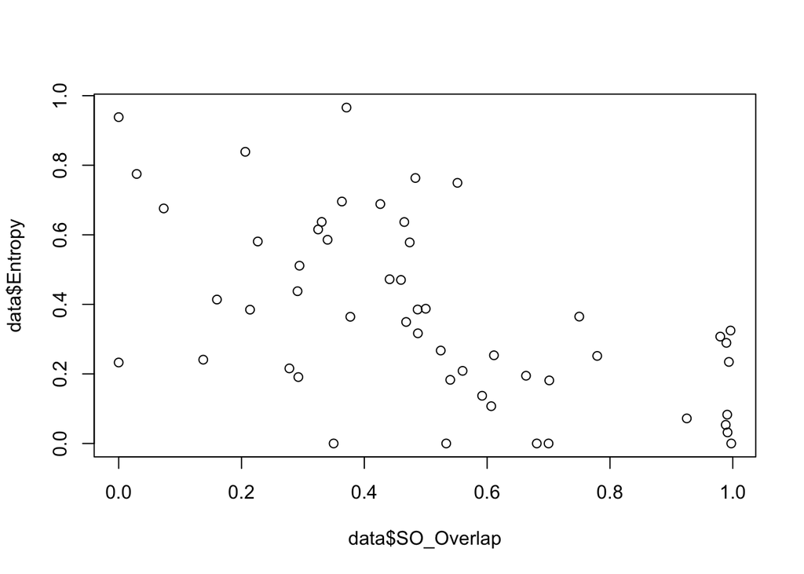

```r
plot(data$SO_Overlap, data$Entropy)
```

## A naïve model

We first fit a Bayesian model without any genealogical or geographic information. Before doing so, we define weakly informative priors.

```r
my_prior_fixed <- set_prior("normal(0, 5)", class = "b")
```

Our first model has 4 MCMC chains (the default) and 4000 iterations per chain. It is usually more efficient to use parallel computing across 4 or more cores (cores = 4).

```r
brm_naive <- brm(Entropy ~ SO_Overlap, data = data, cores = 4, chains = 4, iter = 4000, prior = my_prior_fixed)
```

The coefficients and other useful information are accessed using summary():

```r
summary(brm_naive)
```

```
##  Family: gaussian
##   Links: mu = identity
## Formula: Entropy ~ SO_Overlap
##    Data: data (Number of observations: 53)
##   Draws: 4 chains, each with iter = 4000; warmup = 2000; thin = 1;
##          total post-warmup draws = 8000
##
## Regression Coefficients:
##            Estimate Est.Error l-95% CI u-95% CI Rhat Bulk_ESS Tail_ESS
## Intercept      0.64      0.06     0.51     0.77 1.00     7115     5358
## SO_Overlap    -0.52      0.11    -0.75    -0.31 1.00     7356     5635
##
## Further Distributional Parameters:
##       Estimate Est.Error l-95% CI u-95% CI Rhat Bulk_ESS Tail_ESS
## sigma     0.22      0.02     0.18     0.27 1.00     6354     4978
##
## Draws were sampled using sampling(NUTS). For each parameter, Bulk_ESS
## and Tail_ESS are effective sample size measures, and Rhat is the potential
## scale reduction factor on split chains (at convergence, Rhat = 1).
```

We can also visualize the effect:

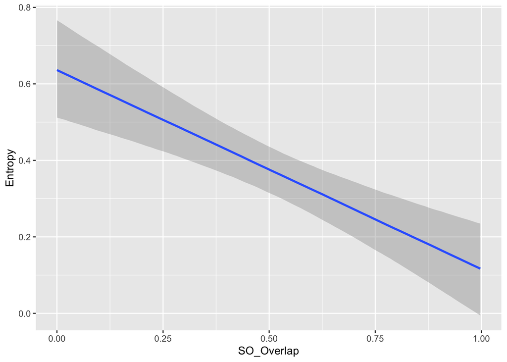

```r
conditional_effects(brm_naive)
```

How good is the model? Let us compute the R2 statistic and perform posterior predictive checks.

```r
bayes_R2(brm_naive)
```

```
##     Estimate  Est.Error      Q2.5     Q97.5
## R2 0.3142248 0.08611981 0.1305144 0.4701547
```

```r
pp_check(brm_naive)
```

```
## Using 10 posterior draws for ppc type 'dens_overlay' by default.
```

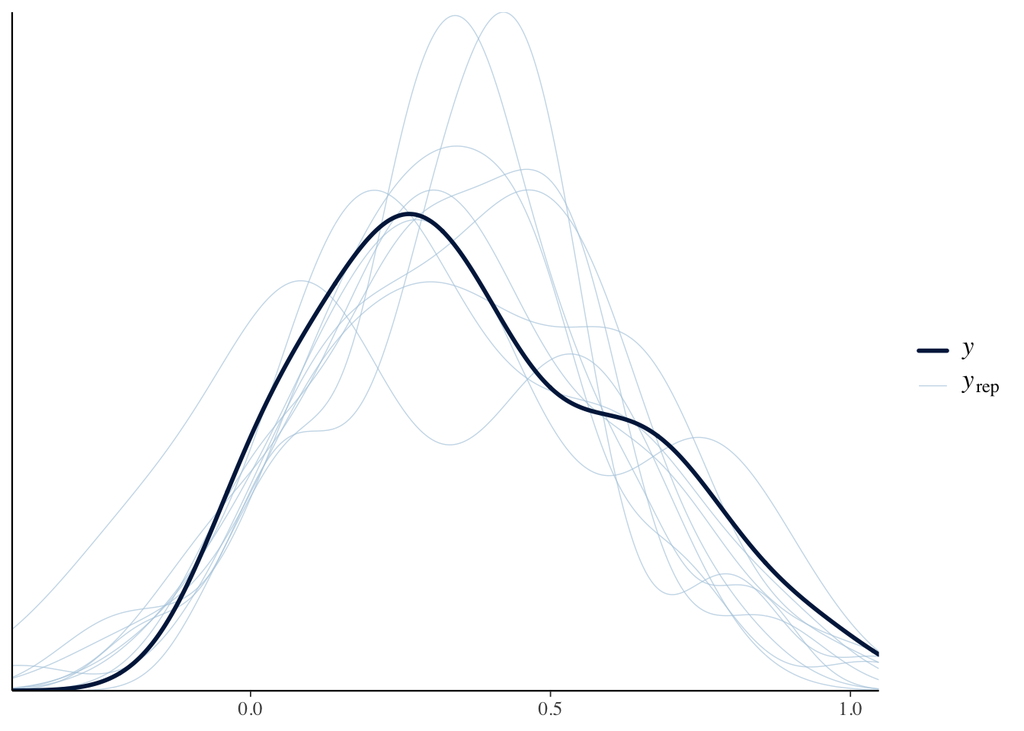

What is the problem?

## Beta regression

Entropy values for a binomial outcome (SO or OS) cannot be greater than 1 and less than 0. We need to switch to beta regression. Before we can fit a beta model, we need to transform the Entropy variable because beta regression cannot deal with values that are strictly equal to 0 or 1.

```r
summary(data$Entropy)
```

```
##    Min. 1st Qu.  Median    Mean 3rd Qu.    Max.
##  0.0000  0.1909  0.3248  0.3706  0.5808  0.9659
```

```r
data$Entropy1 <- data$Entropy
data$Entropy1[data$Entropy == 0] <- 0.001
summary(data$Entropy1)
```

```
##    Min. 1st Qu.  Median    Mean 3rd Qu.    Max.
##  0.0010  0.1909  0.3248  0.3707  0.5808  0.9659
```

Let us refit the model. We will use the same priors as above, but note that in many cases you will need to adjust the priors.

```r
brm_naive_beta <- brm(Entropy1 ~ SO_Overlap, data = data,
                      family = Beta,
                      cores = 4, iter = 4000,
                      prior = my_prior_fixed)
```

What has changed?

```r
summary(brm_naive_beta)
```

```
##  Family: beta
##   Links: mu = logit
## Formula: Entropy1 ~ SO_Overlap
##    Data: data (Number of observations: 53)
##   Draws: 4 chains, each with iter = 4000; warmup = 2000; thin = 1;
##          total post-warmup draws = 8000
##
## Regression Coefficients:
##            Estimate Est.Error l-95% CI u-95% CI Rhat Bulk_ESS Tail_ESS
## Intercept      0.46      0.31    -0.14     1.07 1.00     6689     5307
## SO_Overlap    -2.16      0.56    -3.28    -1.04 1.00     5757     5355
##
## Further Distributional Parameters:
##     Estimate Est.Error l-95% CI u-95% CI Rhat Bulk_ESS Tail_ESS
## phi     2.53      0.45     1.73     3.47 1.00     5625     5669
##
## Draws were sampled using sampling(NUTS). For each parameter, Bulk_ESS
## and Tail_ESS are effective sample size measures, and Rhat is the potential
## scale reduction factor on split chains (at convergence, Rhat = 1).
```

```r
pp_check(brm_naive_beta)
```

```
## Using 10 posterior draws for ppc type 'dens_overlay' by default.
```

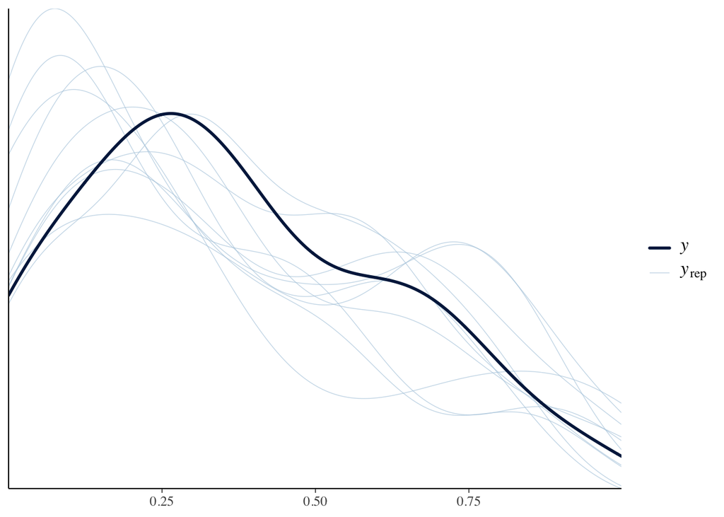

```r
bayes_R2(brm_naive_beta)
```

```
##     Estimate  Est.Error       Q2.5     Q97.5
## R2 0.2578593 0.08882228 0.07525691 0.4175242
```

```r
conditional_effects(brm_naive_beta)
```

```
## Ignoring unknown labels:
## • fill : "NA"
## • colour : "NA"
```

```
## Ignoring unknown labels:
## • fill : "NA"
## • colour : "NA"
```

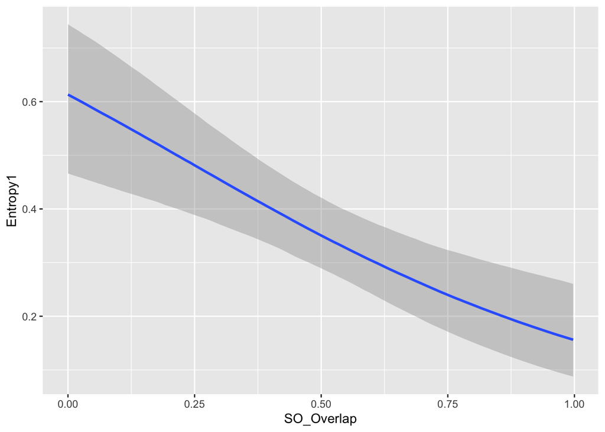

## Mixed-effect modelling

Let us try take into account the phylogenetic information by adding random intercepts for every Genus. We also need to provide priors for the random effects.

```r
my_prior_mixed <- c(set_prior("normal(0, 5)", class = "b"),
                    set_prior("normal(0, 5)", class = "sd"))

brm_genus <- brm(Entropy1 ~ SO_Overlap + (1|genus), data = data,
                      family = Beta,
                      cores = 4, iter = 4000,
                      prior = my_prior_mixed)
```

The results:

```r
summary(brm_genus)
```

```
##  Family: beta
##   Links: mu = logit
## Formula: Entropy1 ~ SO_Overlap + (1 | genus)
##    Data: data (Number of observations: 53)
##   Draws: 4 chains, each with iter = 4000; warmup = 2000; thin = 1;
##          total post-warmup draws = 8000
##
## Multilevel Hyperparameters:
## ~genus (Number of levels: 21)
##               Estimate Est.Error l-95% CI u-95% CI Rhat Bulk_ESS Tail_ESS
## sd(Intercept)     1.39      0.33     0.83     2.14 1.00     2300     3603
##
## Regression Coefficients:
##            Estimate Est.Error l-95% CI u-95% CI Rhat Bulk_ESS Tail_ESS
## Intercept      0.41      0.46    -0.50     1.31 1.00     2470     4148
## SO_Overlap    -2.62      0.69    -3.99    -1.24 1.00     4835     5673
##
## Further Distributional Parameters:
##     Estimate Est.Error l-95% CI u-95% CI Rhat Bulk_ESS Tail_ESS
## phi     7.42      1.88     4.22    11.48 1.00     3624     4622
##
## Draws were sampled using sampling(NUTS). For each parameter, Bulk_ESS
## and Tail_ESS are effective sample size measures, and Rhat is the potential
## scale reduction factor on split chains (at convergence, Rhat = 1).
```

```r
bayes_R2(brm_genus)
```

```
##     Estimate  Est.Error      Q2.5     Q97.5
## R2 0.7154255 0.05786915 0.5741567 0.7979903
```

```r
conditional_effects(brm_naive_beta)
```

```
## Ignoring unknown labels:
## • fill : "NA"
## • colour : "NA"
## Ignoring unknown labels:
## • fill : "NA"
## • colour : "NA"
```

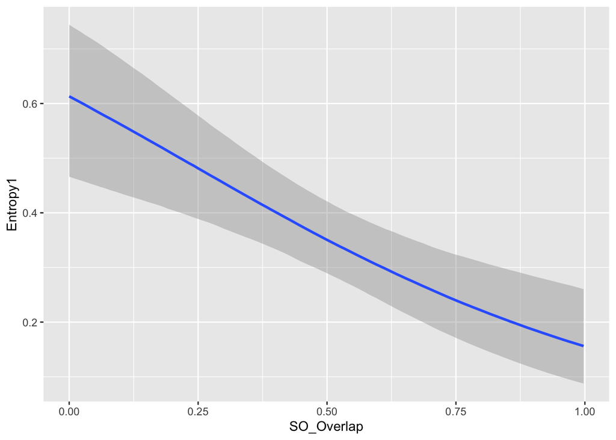

## Which model is better?

```r
brm_naive_beta <- add_criterion(brm_naive_beta, "loo")
brm_genus <- add_criterion(brm_genus, "loo")
```

```
## Warning: Found 9 observations with a pareto_k > 0.7 in model 'brm_genus'. We
## recommend to set 'moment_match = TRUE' in order to perform moment matching for
## problematic observations.
```

To avoid the warning message, we refit the model brm_genus with save_pars = save_pars(all = TRUE) and then improve the LOO estimation. Note that this can take a while.

```r
brm_genus <- brm(Entropy1 ~ SO_Overlap + (1|genus),
                      family = Beta,
                      data = data, cores = 4, iter = 4000,
                      prior = my_prior_mixed,
                      save_pars = save_pars(all = TRUE))
brm_genus <- add_criterion(brm_genus, "loo", moment_match = TRUE)
```

Now we can compare the models:

```r
loo_compare(brm_naive_beta, brm_genus, criterion = "loo")
```

```
##                elpd_diff se_diff
## brm_genus        0.0       0.0
## brm_naive_beta -12.2       4.1
```

The model at the top is better. The ELPD difference should be at least twice as large as its SE. Otherwise, the difference is not considered significant, and we can select the more parsimonious model if we want.

## Our first phylogenetic model

Our first phylogenetic model will include a variance-covariance matrix with covariances (correlations) between all languages in the sample. To create the matrix, we will use some functions from the package glottoTrees:

```r
my_supertree <- assemble_supertree(macro_groups = NULL)
my_supertree <- abridge_labels(my_supertree)
```

[figure not shown]

```r
my_tree <- keep_as_tip(my_supertree, label = data$glottocode)
plot_glotto(my_tree)
```

```r
my_cor <- ape::vcv.phylo(my_tree, corr = TRUE)
print(my_cor[1:10, 1:10])
```

```
##          russ1264 tami1289 mand1415  kaza1248  nucl1301 viet1252  esto1258
## russ1264        1        0        0 0.0000000 0.0000000        0 0.0000000
## tami1289        0        1        0 0.0000000 0.0000000        0 0.0000000
## mand1415        0        0        1 0.0000000 0.0000000        0 0.0000000
## kaza1248        0        0        0 1.0000000 0.3086067        0 0.0000000
## nucl1301        0        0        0 0.3086067 1.0000000        0 0.0000000
## viet1252        0        0        0 0.0000000 0.0000000        1 0.0000000
## esto1258        0        0        0 0.0000000 0.0000000        0 1.0000000
## finn1318        0        0        0 0.0000000 0.0000000        0 0.6172134
## hung1274        0        0        0 0.0000000 0.0000000        0 0.2357023
## nort2671        0        0        0 0.0000000 0.0000000        0 0.1825742
##           finn1318  hung1274  nort2671
## russ1264 0.0000000 0.0000000 0.0000000
## tami1289 0.0000000 0.0000000 0.0000000
## mand1415 0.0000000 0.0000000 0.0000000
## kaza1248 0.0000000 0.0000000 0.0000000
## nucl1301 0.0000000 0.0000000 0.0000000
## viet1252 0.0000000 0.0000000 0.0000000
## esto1258 0.6172134 0.2357023 0.1825742
## finn1318 1.0000000 0.2182179 0.1690309
## hung1274 0.2182179 1.0000000 0.2581989
## nort2671 0.1690309 0.2581989 1.0000000
```

See more information about these and other functions in this useful tutorial: https://ladal.edu.au/tutorials/phylogenetic_methods/phylogenetic_methods.html. Now we are ready to fit our first phylogenetic model:

```r
brm_phylo <- brm(Entropy1 ~ SO_Overlap +
                   (1 |gr(glottocode, cov = my_cor)),
                 family = Beta, data = data,
                 data2 =list(my_cor = my_cor), cores = 4, prior = my_prior_mixed,
                 iter = 4000, control = list(adapt_delta = 0.99))
summary(brm_phylo)
```

```
##  Family: beta
##   Links: mu = logit
## Formula: Entropy1 ~ SO_Overlap + (1 | gr(glottocode, cov = my_cor))
##    Data: data (Number of observations: 53)
##   Draws: 4 chains, each with iter = 4000; warmup = 2000; thin = 1;
##          total post-warmup draws = 8000
##
## Multilevel Hyperparameters:
## ~glottocode (Number of levels: 53)
##               Estimate Est.Error l-95% CI u-95% CI Rhat Bulk_ESS Tail_ESS
## sd(Intercept)     1.38      0.27     0.88     1.94 1.00      794     1463
##
## Regression Coefficients:
##            Estimate Est.Error l-95% CI u-95% CI Rhat Bulk_ESS Tail_ESS
## Intercept      0.47      0.52    -0.57     1.51 1.00     2363     3162
## SO_Overlap    -2.89      0.75    -4.41    -1.43 1.00     2924     4167
##
## Further Distributional Parameters:
##     Estimate Est.Error l-95% CI u-95% CI Rhat Bulk_ESS Tail_ESS
## phi    18.52     18.23     5.31    57.16 1.00      591      710
##
## Draws were sampled using sampling(NUTS). For each parameter, Bulk_ESS
## and Tail_ESS are effective sample size measures, and Rhat is the potential
## scale reduction factor on split chains (at convergence, Rhat = 1).
```

There are some numeric problems. It seems that there is not enough data for this complex structure. Let us simplify the random effect structure by pruning the phylogenetic tree and using only information about the genera and above.

```r
my_tree1 <- keep_as_tip(my_supertree, label = data$glottocode_genus)
```

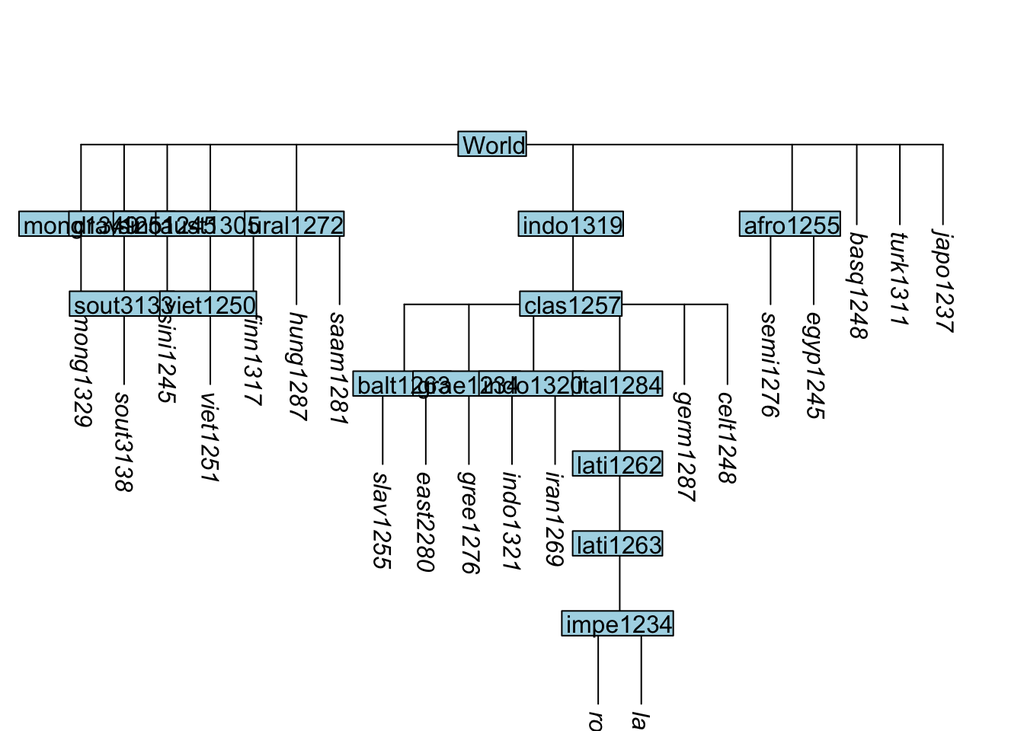

```r
plot_glotto(my_tree1)
```

```r
my_cor1 <- ape::vcv.phylo(my_tree1, corr = TRUE)
```

```r
brm_phylo1 <- brm(Entropy1 ~ SO_Overlap +
                   (1 |gr(glottocode_genus, cov = my_cor1)),
                 family = Beta, data = data,
                 data2 =list(my_cor1 = my_cor1), cores = 4, prior = my_prior_mixed,
                 iter = 4000, control = list(adapt_delta = 0.99),
                 save_pars = save_pars(all = TRUE))
```

```r
summary(brm_phylo1)
```

```
##  Family: beta
##   Links: mu = logit
## Formula: Entropy1 ~ SO_Overlap + (1 | gr(glottocode_genus, cov = my_cor1))
##    Data: data (Number of observations: 53)
##   Draws: 4 chains, each with iter = 4000; warmup = 2000; thin = 1;
##          total post-warmup draws = 8000
##
## Multilevel Hyperparameters:
## ~glottocode_genus (Number of levels: 21)
##               Estimate Est.Error l-95% CI u-95% CI Rhat Bulk_ESS Tail_ESS
## sd(Intercept)     1.61      0.38     0.99     2.46 1.00     1974     3568
##
## Regression Coefficients:
##            Estimate Est.Error l-95% CI u-95% CI Rhat Bulk_ESS Tail_ESS
## Intercept      0.64      0.59    -0.52     1.82 1.00     2664     3865
## SO_Overlap    -2.72      0.69    -4.10    -1.37 1.00     4769     5984
##
## Further Distributional Parameters:
##     Estimate Est.Error l-95% CI u-95% CI Rhat Bulk_ESS Tail_ESS
## phi     7.50      1.80     4.35    11.38 1.00     3934     4875
##
## Draws were sampled using sampling(NUTS). For each parameter, Bulk_ESS
## and Tail_ESS are effective sample size measures, and Rhat is the potential
## scale reduction factor on split chains (at convergence, Rhat = 1).
```

Is this model better than the other two?

```r
brm_phylo1 <- add_criterion(brm_phylo1, "loo", moment_match = TRUE) #this can take a while
loo_compare(brm_naive_beta, brm_genus, brm_phylo1, criterion = "loo")
```

```
##                elpd_diff se_diff
## brm_phylo1       0.0       0.0
## brm_genus       -2.0       1.6
## brm_naive_beta -14.3       4.5
```

## Adding geographic information

How to test geographic dependencies between the languages? We do not have enough data to test macroareas:

```r
table(data$macroarea)
```

```
##
##  Africa Eurasia
##       2      50
```

In this situation, we can start directly with Gaussian Processes:

```r
my_prior_gp <- c(set_prior("normal(0, 5)", class = "b"),
              set_prior("normal(0, 5)", class = "sdgp"))
```

```r
brm_gp <- brm(Entropy1 ~ SO_Overlap +
                gp(longitude, latitude),
              family = Beta, data = data,
              cores = 4,
              iter = 4000, prior = my_prior_gp,
              control = list(adapt_delta = 0.999), save_pars = save_pars(all = TRUE))
```

```r
summary(brm_gp)
```

```
##  Family: beta
##   Links: mu = logit
## Formula: Entropy1 ~ SO_Overlap + gp(longitude, latitude)
##    Data: data (Number of observations: 53)
##   Draws: 4 chains, each with iter = 4000; warmup = 2000; thin = 1;
##          total post-warmup draws = 8000
##
## Gaussian Process Hyperparameters:
##                             Estimate Est.Error l-95% CI u-95% CI Rhat Bulk_ESS
## sdgp(gplongitudelatitude)       1.10      0.29     0.55     1.72 1.00     1143
## lscale(gplongitudelatitude)     0.04      0.02     0.01     0.11 1.01      611
##                             Tail_ESS
## sdgp(gplongitudelatitude)       1854
## lscale(gplongitudelatitude)      713
##
## Regression Coefficients:
##            Estimate Est.Error l-95% CI u-95% CI Rhat Bulk_ESS Tail_ESS
## Intercept      0.43      0.43    -0.41     1.26 1.00     4270     4706
## SO_Overlap    -2.75      0.64    -4.00    -1.48 1.00     4839     5831
##
## Further Distributional Parameters:
##     Estimate Est.Error l-95% CI u-95% CI Rhat Bulk_ESS Tail_ESS
## phi     8.26      4.36     3.19    19.18 1.00      536     1364
##
## Draws were sampled using sampling(NUTS). For each parameter, Bulk_ESS
## and Tail_ESS are effective sample size measures, and Rhat is the potential
## scale reduction factor on split chains (at convergence, Rhat = 1).
```

Is this model better or worse than the previous ones?

```r
brm_gp <- add_criterion(brm_gp, "loo", moment_match = TRUE) #this can take long
loo_compare(brm_naive_beta, brm_genus, brm_phylo1, brm_gp, criterion = "loo")
```

```
##                elpd_diff se_diff
## brm_phylo1       0.0       0.0
## brm_genus       -2.0       1.6
## brm_gp          -6.4       4.8
## brm_naive_beta -14.3       4.5
```

Which model is the winner? What can we conclude from the results?